# Strategic Expectation Setting for Delivery Time in Marketplaces

Arslan Aziz and Amit Mehra

## Summary

Delivery speed is an essential component of the service provided by online delivery platforms. Since establishing a quicker supply chain is expensive, another strategy to manage consumer satisfaction is to set delivery time expectations strategically. In this paper, we use detailed transaction-level data from a hyper-local food delivery platform to examine the effects of setting expected delivery times and their consequences for consumer satisfaction and choice of restaurant. We use high-dimensional fixed effects and instrumental variables for inference. We find that consumers do react to set expectations: they are more likely to purchase from the platform and the same restaurant, and less likely to purchase from other restaurants, when delivery is earlier than estimated. We also find that more experienced consumers are less influenced by delivery performance, likely due to the prior delivery signals received from previous transactions on the platform.

### Data

We have transaction-level data from a hyper-local food delivery platform. For each transaction, we observe the estimated time of delivery, actual time of delivery, as well as other characteristics such as displayed rating of the restaurant, feedback ratings provided by the user after the transaction, amount spent, whether there was a delivery charge, and if it is the user’s first transaction on the platform. For our main outcome variables, we create binary variables for whether the user purchases again from the platform, from the same restaurant, and from other restaurants on the platform in the next week or 2 weeks. The variables are described in Table 1 and summarized in Table 2.

##### Table 1: Data Description

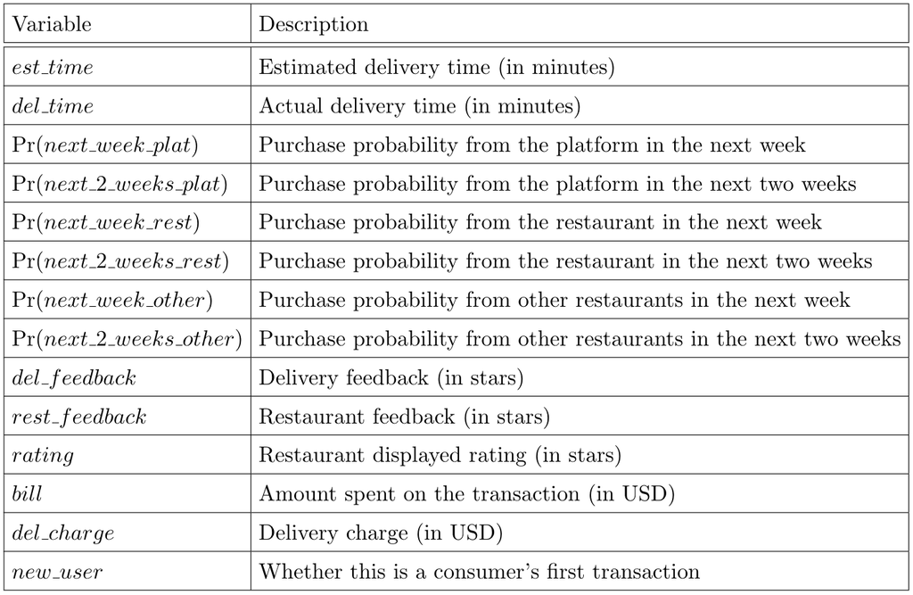

#### Table 2: Summary Statistics

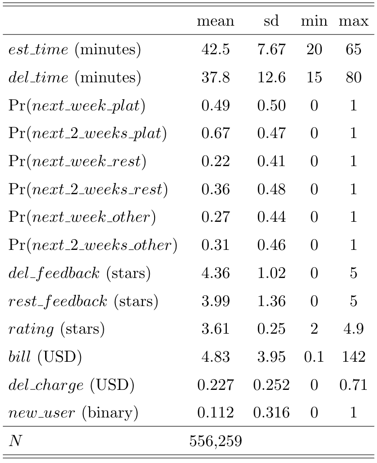

### Exploratory Data Analysis

We perform some exploratory data analysis to understand it better. We find in Figure 2 that about 30% of orders are delivered late, and in Figure 3, that orders with very short estimated delivery times are late on average.

#### Figure 2: Histogram of late deliveries. Positive value indicates late delivery. About 30% of orders are delivered late.

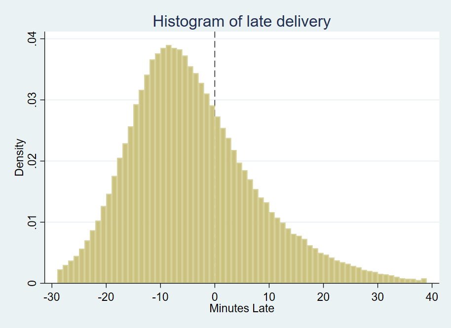

#### Figure 3: Actual versus estimated delivery time. Very short estimated times are late on average, and longer estimated times are early.

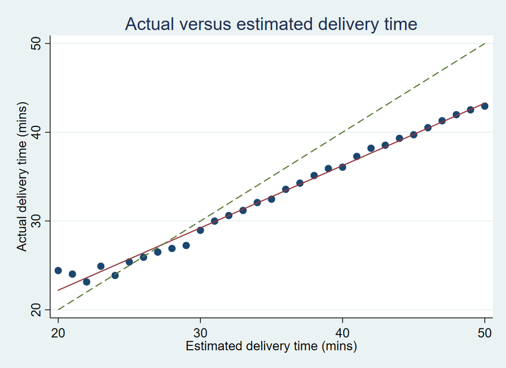

Sales on the platform exhibit strong weekly trends, with weekends having almost twice the sales of weekdays.

#### Figure 4: Daily sales on the platform. Weekends have almost twice the sales of weekdays.

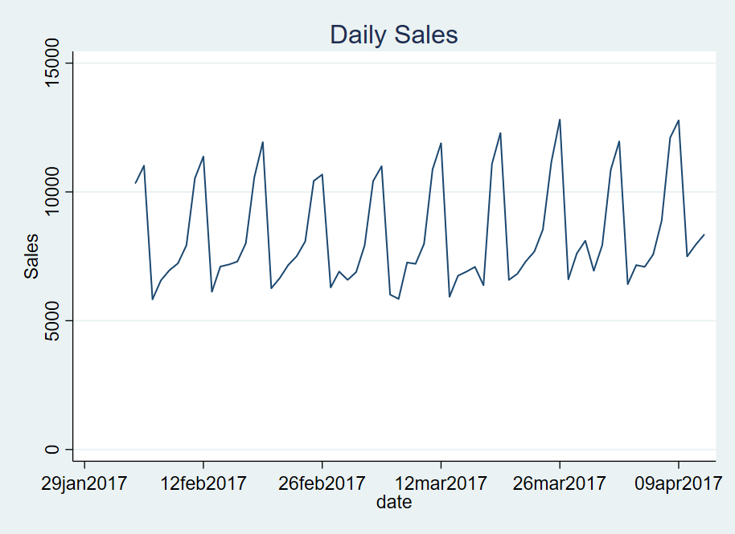

There is a long-tail of consumers with few consumers purchasing heavily, while the majority purchase very few times during the period of observation.

#### Figure 5: Histograms of consumer purchases. Most consumers make few purchases.

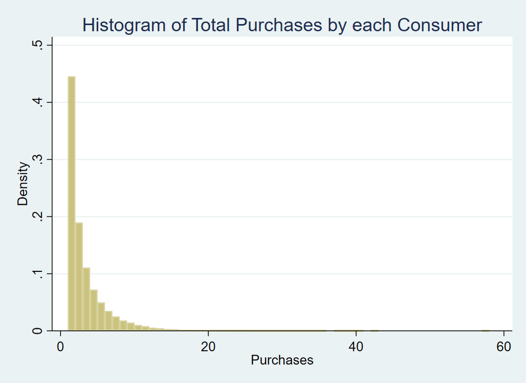

We find the well-document J-curve for delivery and restaurant feedback ratings. Most ratings are positive (4 or 5 stars), with few intermediate ratings.

#### Figure 6: Histograms of delivery and restaurant feedback ratings.

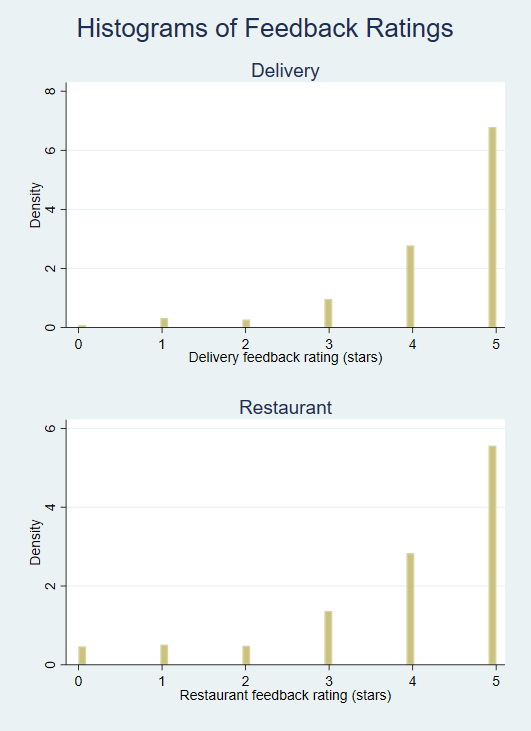

### Results

To estimate the causal effect of the estimated time on future purchase probability, we cannot merely regress the outcome on the independent variables and interpret the coefficient as the causal effect. Such a coefficient would likely be biased since it could be influenced by variables that are correlated with the estimated time, yet unobserved. To account for such a source of endogeneity, we use the instrumental variable method. By finding a variable that is correlated with the variable of interested (estimated time), yet that is unlikely to influence the outcome variable directly, we are able to find a causal estimate of the variable of interest on the outcome variable. We use the average estimated time for delivery for all other transactions from a restaurant on the same day as the instrumental variable. Estimated times for other customers should not directly influence a customer’s satisfaction, and hence their future purchase probability, except through influencing their estimated time. In the tables below, we show the results of the instrumental variable estimation. We also use numerous controls and high-dimensional fixed effects to control for other factors affecting the outcome variable.

As can be seen in Tables 3, 4, and 5, a longer estimated time increases the purchase probability from the platform and the same restaurant, and decreases it for other restaurants. We have controlled for the actual delivery time, the restaurant quality, amounts charged etc. Thus, early delivery benefits the platform and the restaurant, while other restaurants are negatively impacted. This suggests an incentive for restaurants to enable quick delivery to compete with other restaurants on the platform.

#### Table 3: Probability of purchasing from the platform

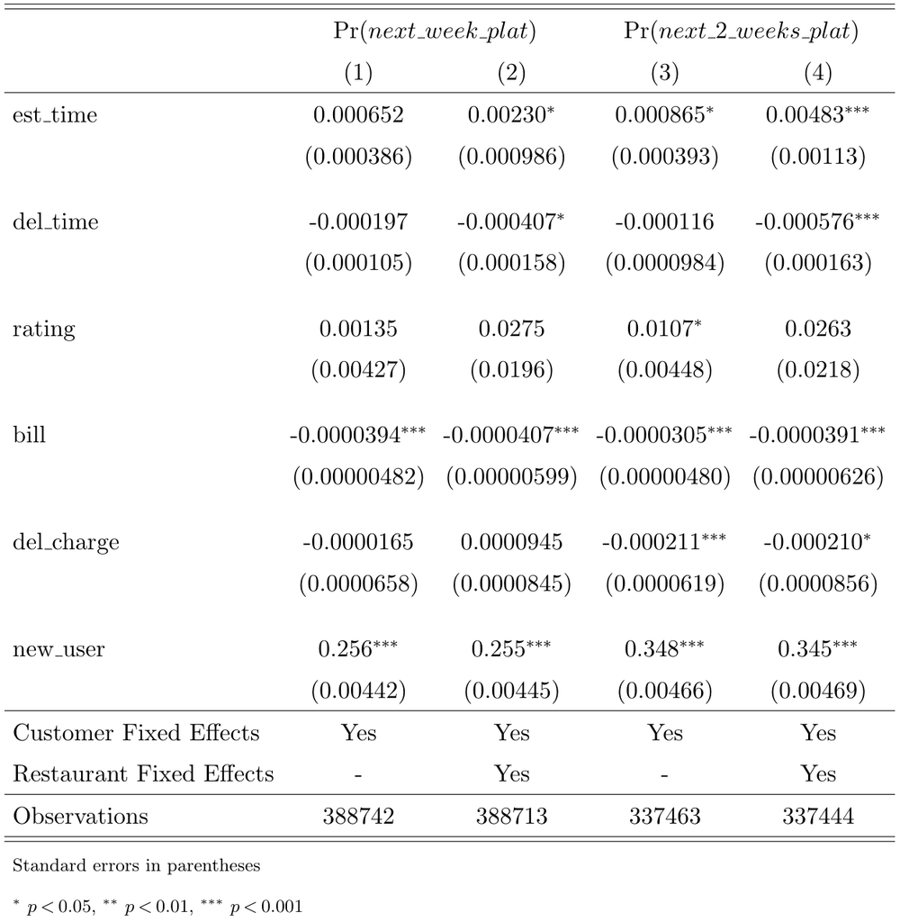

#### Table 4: Probability of purchasing from the same restaurant

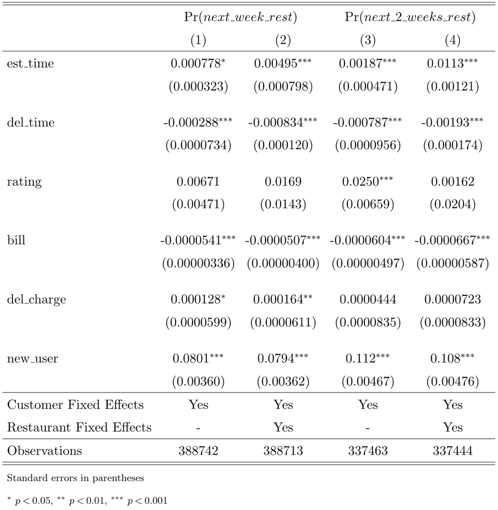

#### Table 5: Probability of purchasing from other restaurants

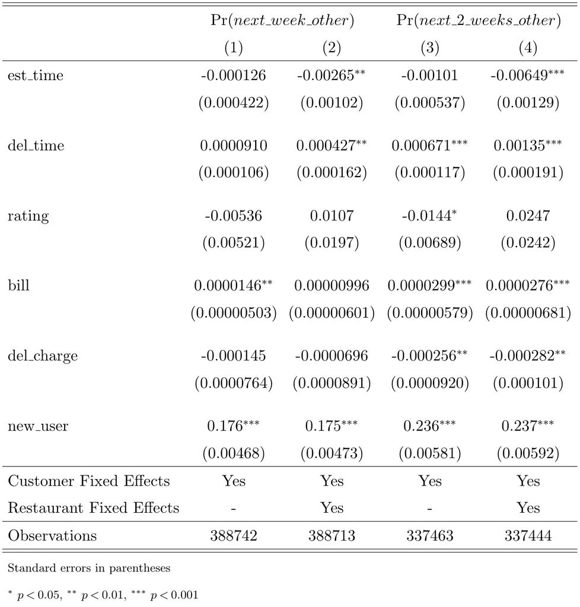

We also examine if consumer’s response to early/late delivery depends on their frequency of purchasing from the platform. In Table 6, by taking the interaction term of est_time and purchase_count, we find that over a 2 week period, customers with a high frequency of purchase are less affected by delivery performance than less frequent purchasers. This has implications for how a platform can prioritize delivery for different types of customers based on their tolerance of late delivery.

#### Table 6: Probability of purchasing from the platform based on purchase count

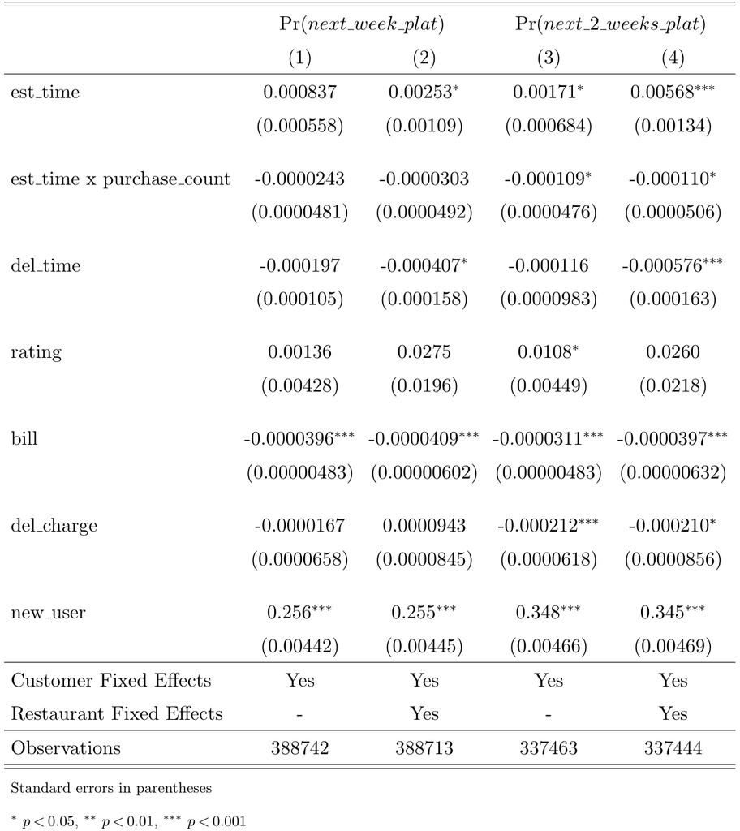